# JSC370 Midterm Project: Impact of Weather on TTC Delays

Author

Xiran Yin

# 1 Introduction

Public transit systems play a critical role in supporting urban mobility. However, their reliability can be affected by environmental factors, particularly adverse weather conditions. In Toronto, a large metropolitan area, the Toronto Transit Commission (TTC) serves over one million daily riders, making service reliability an important component of urban infrastructure. Weather-related disruptions can lead to delays that affect commuting times, operational efficiency, and overall system performance. Understanding how weather conditions relate to transit delays can therefore provide useful insights for transit planning and operational decision-making. This project examines the relationship between daily weather conditions and TTC subway delays by combining more than a decade(12 years) of meteorological observations with publicly available transit delay records. By integrating these datasets, the analysis aims to quantify how different weather conditions correspond to variations in delay frequency and duration. The primary research questions guiding this analysis are:

1. Is there a statistically significant association between adverse weather (specifically precipitation volume and extreme temperatures) and the total duration of daily TTC delays?
2. How does the distribution of delay incidents vary across discrete weather categories (Clear, Light Rain/Snow, Heavy Rain/Snow)?
3. Do temporal factors — month of year, day of week, and weekend vs. weekday status — independently moderate the weather–delay relationship once precipitation is controlled for?
4. Is the precipitation–delay relationship linear, or does it exhibit non-linear saturation behaviour?

**Hypotheses:**

- H₀: Precipitation volume has no effect on total daily TTC delay duration (β_precip = 0).
- H₁: Higher precipitation is positively associated with greater total delay (β_precip > 0), with the effect potentially non-linear at higher precipitation volumes.

The GitHub repository containing the source code (.qmd) and rendered report(.html) for this project is available at: https://github.com/xiran-yin/JSC370.git.

# 2 Methods

## 2.1 Data Sources

Two independent datasets were used in this study.

## 2.2 Data Acquisition

**Weather** data were retrieved programmatically from the Open-Meteo Historical Weather API. A single HTTP GET request was constructed using Toronto’s geographic coordinates (latitude 43.7064°N, longitude −79.3986°W) and a date range spanning January 2014 to January 2026. The API returned daily meteorological observations in JSON format. Each record contained a calendar date and eight meteorological variables: daily maximum and minimum temperature (°C), apparent temperature maximum (°C), total precipitation (mm), precipitation duration (hours), snowfall (cm), maximum 10-m wind speed (km/h), and maximum wind gust speed (km/h). From these variables, four additional features were derived to better capture weather conditions that may affect transit reliability. Precipitation intensity was calculated as total precipitation divided by precipitation duration (mm/hour) to distinguish short downpours from long periods of light rain. Binary indicators were also created for freezing nights (minimum temperature < 0 °C), heatwave days (maximum temperature > 32 °C, following Environment Canada’s definition), and stormy conditions (maximum gust speed > 50 km/h).

**TTC subway delay** data were retrieved programmatically via the City of Toronto Open Data CKAN API. The API returned a catalogue of historical resources across multiple years, presenting several data wrangling challenges. First, the files included both CSV and Excel formats, requiring conditional parsing. Second, column naming conventions varied significantly across years (e.g., “Date” vs. “Occurrence Date”, “Min Delay” vs. “min_delay”). To robustly clean this data, a flexible substring matching approach was implemented to dynamically identify the relevant date and delay-duration fields. Exception handling was also applied to manage file encoding errors and drop incomplete records. After standardizing the schema, all records were concatenated and aggregated to the daily level, yielding two primary metrics per date: total delay duration (minutes) and total delay incidents.

## 2.3 Data Cleaning and Feature Engineering

Following the initial data acquisition and pre-processing, the aggregated daily TTC records and weather data were combined via an inner join on the date field. To facilitate the regression analysis, additional temporal and categorical features were engineered on this merged dataset. Building upon the initial meteorological indicators, a comprehensive three-level weather severity categorical variable (Clear / Light Rain/Snow / Heavy Rain/Snow) was created. Furthermore, temporal factors—such as month, day of the week, and a weekend/weekday flag—were extracted, alongside a newly computed delay severity index (average delay per incident). The final analytic dataset contains 2833 observations across 28 variables (detailed in Table 1), spanning January 1, 2014, to January 1, 2026.

**Data Dictionary (click to expand)**

Table 1: Data Dictionary of Variables Used in the Analysis

| Variable | Category | Description |
| --- | --- | --- |
| date | Base | Calendar date of the observation (YYYY-MM-DD) |
| total_delay_mins | Target | Total duration of all subway delays for the day (minutes) |
| total_incidents | Target | Total count of individual subway delay incidents |
| avg_delay_per_incident | Derived Target | Average duration per delay incident (total_delay_mins / total_incidents) |
| severity_index | Derived Target | Copy of avg_delay_per_incident used as a severity metric |
| temp_max | Weather | Maximum daily temperature (°C) |
| temp_min | Weather | Minimum daily temperature (°C) |
| feels_like | Weather | Maximum apparent (‘feels like’) temperature (°C) |
| mean_temp_c | Derived Weather | Average of daily maximum and minimum temperatures (°C) |
| precip_mm | Weather | Total daily precipitation (mm) |
| precip_hours | Weather | Total hours of precipitation |
| snowfall_cm | Weather | Total daily snowfall (cm) |
| max_wind_v | Weather | Maximum 10-m wind speed (km/h) |
| gust_speed | Weather | Maximum wind gust speed (km/h) |
| precip_intensity | Derived Weather | Calculated precipitation intensity (mm/hour) |
| is_freezing | Derived Weather | Boolean: True if temp_min < 0°C |
| is_heatwave | Derived Weather | Boolean: True if temp_max > 32°C |
| is_stormy | Derived Weather | Boolean: True if gust_speed > 50 km/h |
| weather_type | Derived Weather | Categorical: ‘Clear’, ‘Light Rain/Snow’, or ‘Heavy Rain/Snow’ |
| year | Temporal | Year of the observation |
| month | Temporal | Full name of the month (e.g., ‘January’) |
| month_num | Temporal | Month number (1-12) |
| month_abbr | Temporal | Abbreviated month name (e.g., ‘Jan’) |
| month_cat | Temporal | Unordered categorical format of the month for regression |
| day_of_week | Temporal | Name of the day of the week (e.g., ‘Monday’) |
| day_type | Temporal | String: ‘Weekend’ or ‘Weekday’ |
| is_weekend | Temporal | Boolean: True if Saturday or Sunday |
| is_weekend_int | Temporal | Integer boolean: 1 for Weekend, 0 for Weekday |

## 2.4 Statistical Methods

The following statistical tools were used for data exploration and analysis:

- **Spearman rank correlation** to assess monotonic associations between weather variables and delay metrics, chosen because both delay totals and precipitation are strongly right-skewed.
- **OLS multiple linear regression** to establish a baseline model evaluating the linear effects of weather predictors (precipitation, snowfall, gust speed, temperature) while controlling for weekend and month fixed effects.
- **Generalized Additive Model (GAM)** with spline smooths on precipitation and temperature to capture non-linear relationships, and factor terms for weekend status and month.
- **STL time-series decomposition** to separate long-term trend, weekly seasonality, and residual weather spikes.
- **Natural Language Processing (NLP)**: Applied VADER sentiment analysis to quantify rider emotional responses to delays, and LDA topic modelling to identify dominant complaint themes in Reddit (r/TTC) discourse.

# 3 Preliminary Results

## 3.1 Summary Statistics

The final analytic dataset comprises 2,833 daily observations spanning 2014–2025. System-wide total delay averaged 153 minutes per day (SD = 106, range: 4–2,342 min), with substantial right skew driven by extreme weather events. On a typical day, approximately 61 delay incidents were recorded. Toronto’s mean daily temperature ranged from −21°C to 31°C over the study period, while daily precipitation reached as high as 48 mm and snowfall as high as 24.6 cm. Maximum gust speeds averaged 41 km/h, with an observed maximum of 103 km/h.（Shown in Table 2）

Table 2: Descriptive statistics of key variables in the merged dataset (2014–2025).

**Table 2.** Descriptive statistics of key variables.

|  | N | Mean | SD | Min | Q1 | Median | Q3 | Max |
| --- | --- | --- | --- | --- | --- | --- | --- | --- |
| Total Delay (min) | 2833 | 153.17 | 105.58 | 4 | 89 | 133 | 192 | 2342 |
| Total Incidents | 2833 | 60.73 | 15.8 | 18 | 50 | 60 | 70 | 144 |
| Mean Temp (°C) | 2833 | 8.04 | 10.32 | -21.3 | 0.25 | 7.8 | 17.35 | 31.35 |
| Precipitation (mm) | 2833 | 2.32 | 5.03 | 0 | 0 | 0.1 | 2 | 48 |
| Snowfall (cm) | 2833 | 0.28 | 1.18 | 0 | 0 | 0 | 0 | 24.57 |
| Gust Speed (km/h) | 2833 | 41.27 | 12.72 | 13.7 | 31.7 | 39.6 | 49 | 103 |

The merged dataset spans over a decade of daily observations with no missing values in key variables. As shown in Table Table 3, average daily delay increases monotonically from Clear days through Light Rain/Snow to Heavy Rain/Snow days, with Heavy precipitation days showing the widest spread (largest SD), consistent with unpredictable infrastructure stress. These patterns directly support H₁ and motivate formal regression testing.

Table 3: Summary statistics of delay metrics by weather type category.

**Table 3.** Summary statistics by weather type.

| Weather Type | N (days) | Mean Delay (min) | SD Delay | Median Delay (min) | Mean Incidents | Mean Severity (min/incident) |
| --- | --- | --- | --- | --- | --- | --- |
| Clear | 1297 | 144.43 | 91.98 | 127 | 59.33 | 2.43 |
| Light Rain/Snow | 1323 | 155.03 | 93.05 | 137 | 61.49 | 2.51 |
| Heavy Rain/Snow | 213 | 194.91 | 202.36 | 155 | 64.54 | 2.88 |

## 3.2 STL Decomposition of Daily Delays

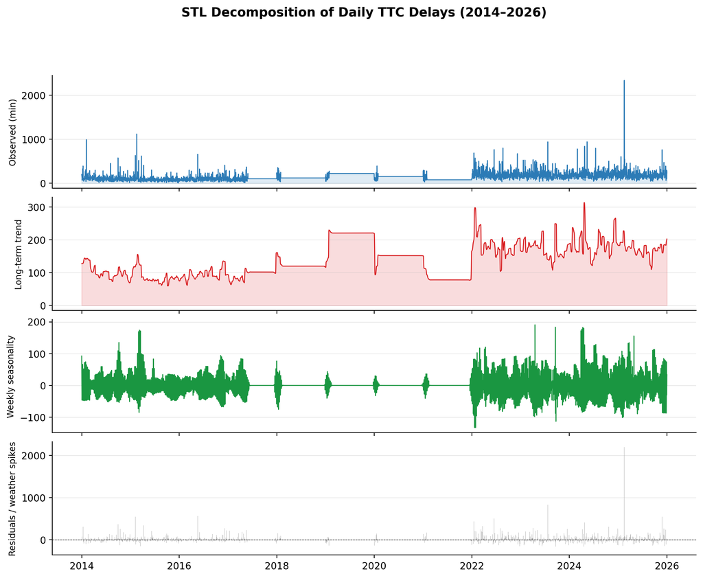

**Figure 1.** STL decomposition separating the long-term trend, weekly seasonality, and residual weather spikes in daily TTC delays.

## 3.3 Average Delay Heatmap: Day of Week × Month

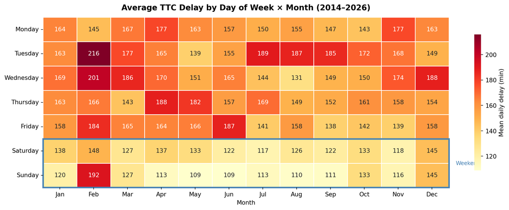

**Figure 2.** Two-way interaction heatmap of mean daily delay by weekday and calendar month.

## 3.4 Faceted Scatterplot: Precipitation vs. Delay

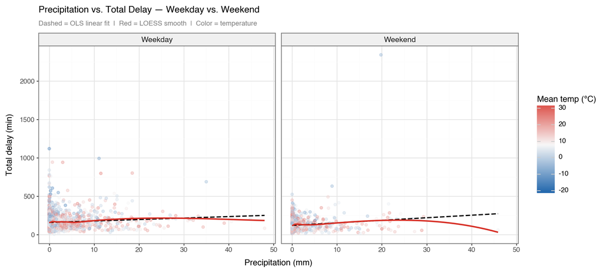

**Figure 3.** Precipitation vs. total delay faceted by day type, with OLS (dashed) and LOESS (red) smooth fits. Point colour encodes mean daily temperature.

## 3.5 Spearman Correlation Heatmap

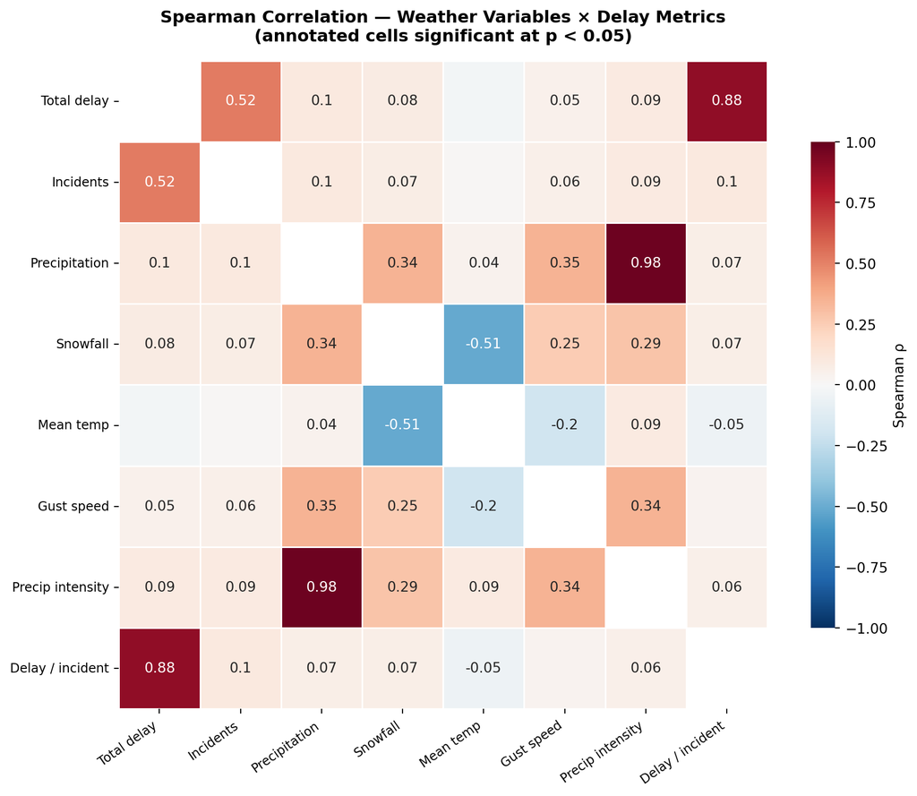

**Figure 4.** Spearman correlation matrix across weather and delay variables. Cells with p ≥ 0.05 are left blank.

## 3.6 OLS Multiple Linear Regression

**Table 3.** OLS regression results (R² = 0.068, Adjusted R² = 0.062, F-test p < 0.001). Month fixed effects included but omitted for brevity.

| Predictor | Coefficient | Std Error | t-value | p-value |
| --- | --- | --- | --- | --- |
| Precipitation (mm) | 1.196 | 0.428 | 2.8 | 0.0052 |
| Snowfall (cm) | 15.842 | 1.816 | 8.72 | < 0.001 |
| Gust Speed (km/h) | -0.144 | 0.165 | -0.87 | 0.3844 |
| Mean Temperature (°C) | -0.071 | 0.448 | -0.16 | 0.8739 |
| Weekend (indicator) | -35.675 | 4.257 | -8.38 | < 0.001 |

## 3.8 NLP and Sentiment Analysis of Rider Discourse

Reddit posts from r/TTC provide an independent, qualitative window into rider experience. Two complementary NLP methods were applied: VADER sentiment analysis to quantify emotional tone, and LDA topic modelling to identify dominant complaint themes. The two methods answer *how angry* riders are and *what* they are angry about, respectively — together addressing VADER’s known limitation of performing poorly on domain-specific sarcasm and technical vocabulary.

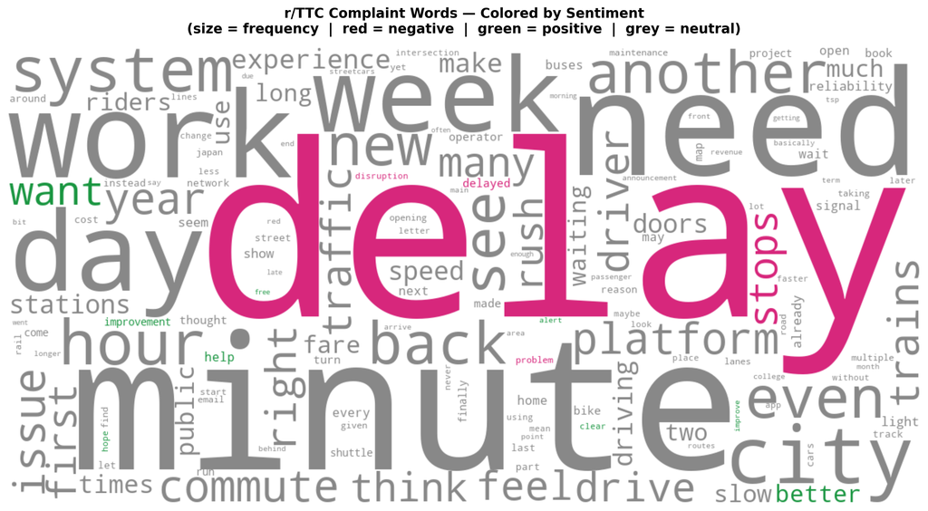

Figure 1: **Figure 6.** r/TTC word cloud. Size = term frequency; colour = VADER sentiment (red = negative, green = positive, grey = neutral).

**Table 4.** LDA topic model results (k = 4). Top 10 words per topic.

| Topic | Top 10 Words |
| --- | --- |
| Topic 1 | minutes, work, delays, another, right, day, driving, drive, new, 10 |
| Topic 2 | delays, delay, com, ca, back, comments, app, www, trains, reddit |
| Topic 3 | delays, city, issues, ca, stops, system, may, also, delay, reliability |
| Topic 4 | platform, trains, stations, long, japan, doors, public, even, need, times |

A total of 100 Reddit posts mentioning delays were retrieved from r/TTC. The word cloud (Figure 6) reveals that the most frequent complaint terms are operationally specific — terms like “delay,” “minute,” and “hour” dominate by size, confirming posts are genuinely delay-focused rather than general transit discussion. Red-coloured (negative) words cluster around service failure language, while grey (neutral) terms reflect procedural vocabulary.

**Methodological note:** VADER is known to perform poorly on sarcasm and domain-specific technical terms. The LDA topic model mitigates this limitation by providing content-based validation that does not depend on sentiment lexicons.

# 4 Summary

## 4.2 Plan for Final Project

The Final Project will extend this midterm analysis along three dimensions:

1. **Machine Learning Classification:** “Severe Delay Days” will be defined as days in the top quartile of total delay minutes. Three classifiers will be trained and compared on a stratified 70/30 split: Logistic Regression (baseline), Random Forest, and XGBoost. Model evaluation will use accuracy, precision, recall, F1, and ROC-AUC. Feature importance plots will identify which weather variables are most predictive of service-critical disruption.
2. **Geospatial Analysis:** Station-level delay data (available as `station` and `line` columns in the raw TTC records) will be merged with geographic coordinates to identify which stations and subway lines are most vulnerable under specific weather conditions. Folium choropleth maps will visualise station-level delay risk across the TTC network.
3. **Interactive Dashboard on GitHub Pages:** All findings will be packaged into a Plotly Dash or Panel dashboard deployed on GitHub Pages, allowing users to select date ranges, weather thresholds, and TTC lines to dynamically explore weather–delay relationships. This combines the API integration, the NLP pipeline, and the mapping approach into a single publicly accessible transit intelligence tool.